# 2020 데이터 사이언스 수업 전파교육(ITS 공유용)

ITS 정혜지

### **데이터 사이언스의 수업의 전체적인 흐름**

1. Markdown
2. 데이터 사이언스가 무엇인지?
3. 데이터 분석을 위해 필요한 기반 지식 (자료구조, R Tidyverse, git 저장소 구성, blog 제작 .. )
4. 데이터 모델링 기초
5. 데이터 전처리 EDA
6. 데이터 시각화
7. 데이터 검증
8. 프로젝트 진행 - 결과물 소개

# 1 데이터 분석 사전작업!

## 1.1 R Markdown

### 1.1.1 Markdown이란?

- R마크다운은 데이터 분석의 전 과정을 담은 보고서를 쉽게 만들 있는 R의 기능
- R분석 내용을 HTML, 워드, PDF등 여러 포맷으로 저장할 수 있어 다양한 형태의 보고서를 만들기 용이
- 실제 R로 쓰인 코드의 chunk 삽입이 가능하여 논문, 보고서 등의 산출물로 널리 쓰임
- html, css 등을 활용 가능
- 수업에 사용된 모든 자료는 Markdown으로 제작되었으며, 프로젝트 발표시에도 markdown만 사용하기 원칙!
- (참고)[‘https://statkclee.github.io/yonsei/02-rmarkdown/index.html’]

## 1.2 …“데이터 사이언스란..?”

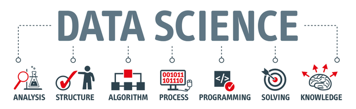

## 1.3 데이터 분석을 위해 필요한 기반 지식

### 1.3.1 자료구조

- 자료형(데이터 타입) / 자료모드(논리형, 문자형, 숫자형) / 범주형, 순서형
- 데이터 프레임(rectangular frame)
- 벡터 (vector)

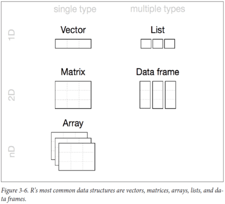

### 1.3.2 R Tidyverse, git 저장소 구성, blog 제작 etc..

- Tidyverse란, R을 이용해 데이터 전처리 및 분석을 유용하게 할 수 있는 일종의 library (package)
- git이라는 형상관리 및 협업관리 도구을 통해 협업하는 과정 및 배포 과정 학습
- r markdown 의 다양한 template을 활용할 수 있는데, 이를 이용해서 blog도 만들어 보았음.

# 2 데이터 분석의 시작!

## 2.1 데이터 전처리 및 탐색적 분석 (Exploratory Data Analysis)

- 데이터를 분석하기 좋도록 가공하고 이해하는 과정
- 상관변수 분석을 통해 결과값에 영향력이 큰 중심 변수를 찾는 과정

## 2.2 데이터 모델링 기초

- 앞의 EDA과정을 통해 도출한 상관변수를 이용하여 결과를 도출
- 지도학습 vs 비지도학습

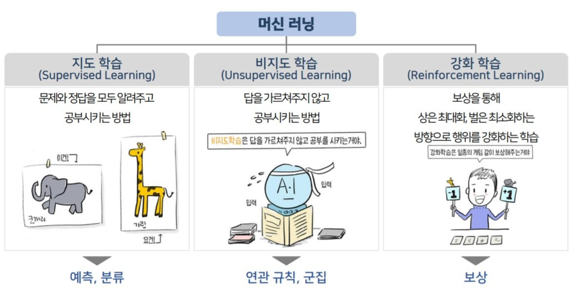

## 2.3 데이터 시각화

- r의 ggplot2, shiny 이용

## 2.4 데이터 검증

- AUC curve, accuracy 측정

# 3 팀별 프로젝트 진행

- [HR Report 시각화 및 퇴사율 분석]